# Film Industry Trends: An Analysis from 1990 to 2025

- Show All Code
- Hide All Code
- View Source

Authors

Hamza Aalaou

Iris Dos Santos Grilo

Soraya Kachache Alaoui

Katarina Ukzmail

Published

November 9, 2025

Abstract

# 1 Introduction

## 1.1 Project Goals

The goal of this project is to analyze the evolution of the global film industry from 1990 to 2025. We aim to understand how public tastes and film characteristics such as, genre, budget, duration, and country of origin, have changed over time. This topic is relevant as it connects art, culture, and data science, allowing us to use data to explore historical and cultural trends in entertainment. By transforming creative aspects of cinema into measurable patterns, we can gain insights into how technology, audience preferences, and globalization have shaped the movies we watch today. The analysis will focus on exploratory data analysis (EDA) to identify major trends and correlations.

## 1.2 Research Questions

Our primary research question is: - How have public tastes and film characteristics (genres, budget, origins, duration) evolved in the global film industry between 1990 and 2025?

To address this, we will investigate the following sub-questions, each providing a different lens through which to view the industry’s evolution: - **Which film genres dominated each decade?** This question helps us understand changing cultural tastes and identify which storytelling formats were most popular in different eras. - **How have movie budgets evolved over time?** Analyzing budget trends reveals the economic shifts in the film industry, from the rise of blockbusters to the impact of new technologies. - **Is there a correlation between a film’s budget and its IMDb rating?** This explores whether higher financial investment typically translates into better audience reception, a key consideration for producers. - **Are modern films longer than those from the 1990s?** The answer to this question can reflect changes in storytelling norms and audience viewing habits. - **Which countries have dominated global film production over different periods?** This highlights the geographical shifts in filmmaking, showing the influence of globalization and the rise of new markets. - **Do the highest-rated films consistently come from the same regions?** This question examines whether critical acclaim is concentrated in specific cultural or geographical areas.

# 2 Data

## 2.1 Sources

Our primary dataset was sourced from Kaggle: **IMDb Movies from 1920 to 2025**, published by Raed Addala. The data was accessed in November 2025. The dataset is available at the following URL: https://www.kaggle.com/datasets/raedaddala/imdb-movies-from-1960-to-2023/data.

## 2.2 Description

The original dataset contains approximately 60,000 movies spanning from 1920 to 2025, with 23 variables for each film. After cleaning and filtering for the 1990–2025 period, our final dataset provides a comprehensive view of the modern film industry.

- **Number of observations**: 21869 rows
- **Number of variables**: 23 columns
- **Time period**: 1990 to 2025
- **Geographic coverage**: Global, with a noted bias towards Western/Hollywood films.
- **Key variables**: `title`, `release_date`, `primary_genre`, `duration_minutes`, `rating`, `votes_numeric`, `budget`, `gross_worldwide`, and `countries_origin`.

## 2.3 Wrangling

### 2.3.1 General Transformations

A separate Python script (`src/clean_data.py`) was used to perform all data preprocessing. This approach keeps our reporting document clean and ensures reproducibility. The key steps performed were:

1. **Filtering by Year**: The dataset was filtered to include only movies released between 1990 and 2025 to align with our research scope.
2. **Duration Conversion**: The `duration` column (e.g., “2h 10m”) was converted into a numerical format in a new `duration_minutes` column.
3. **Currency Cleaning**: Financial columns (`budget`, `gross_worldwide`, etc.) were standardized into a numeric format by removing currency symbols and commas.
4. **Genre Extraction**: A `primary_genre` column was created by extracting the first genre from the `genres` list for each movie, simplifying classification.
5. **Votes Normalization**: The `votes` column was converted to a numeric type (`votes_numeric`), handling abbreviated values (e.g., ‘K’ for thousands, ‘M’ for millions).
6. **Date Conversion**: The `release_date` column was converted to a proper datetime format.

### 2.3.2 Spotting Mistakes and Missing Data

During preprocessing, several data quality issues were identified and addressed:

- **Missing Values**: Many older or less popular films had missing financial data (e.g., `budget`, `gross_worldwide`). Instead of removing these rows, the missing values were kept as `NaN` (Not a Number). This allows us to use the rows for non-financial analysis (like genre or duration trends) while excluding them from financial calculations where necessary.
- **Inconsistent Formatting**: As mentioned, `duration`, `budget`, and `genres` were not in a ready-to-use format. Our script standardized these to ensure they could be used in calculations and analysis.
- **Geographical Bias**: The dataset has a strong bias towards Hollywood and Western cinema. While we cannot “fix” this, we acknowledge this limitation in our analysis. Our findings on “global” trends will be interpreted with this bias in mind.
- **Inflation**: Financial data like `budget` and `gross_worldwide` are not adjusted for inflation. Direct comparisons of monetary values across different decades should be made with caution.
- **Subjective Ratings**: IMDb scores are user-based and can reflect cultural or regional bias.

# 3 Exploratory Data Analysis

In this section, we conduct an exploratory data analysis (EDA) to answer our research sub-questions. Each sub-section addresses one question, providing visualizations and interpretations to uncover patterns in the global film industry from 1990 to 2025.

## 3.1 Q1: Which film genres have dominated each decade?

To understand shifting cultural tastes, we first analyze the prevalence of different film genres over time. We group movies by decade and their primary genre to identify which categories were most produced.

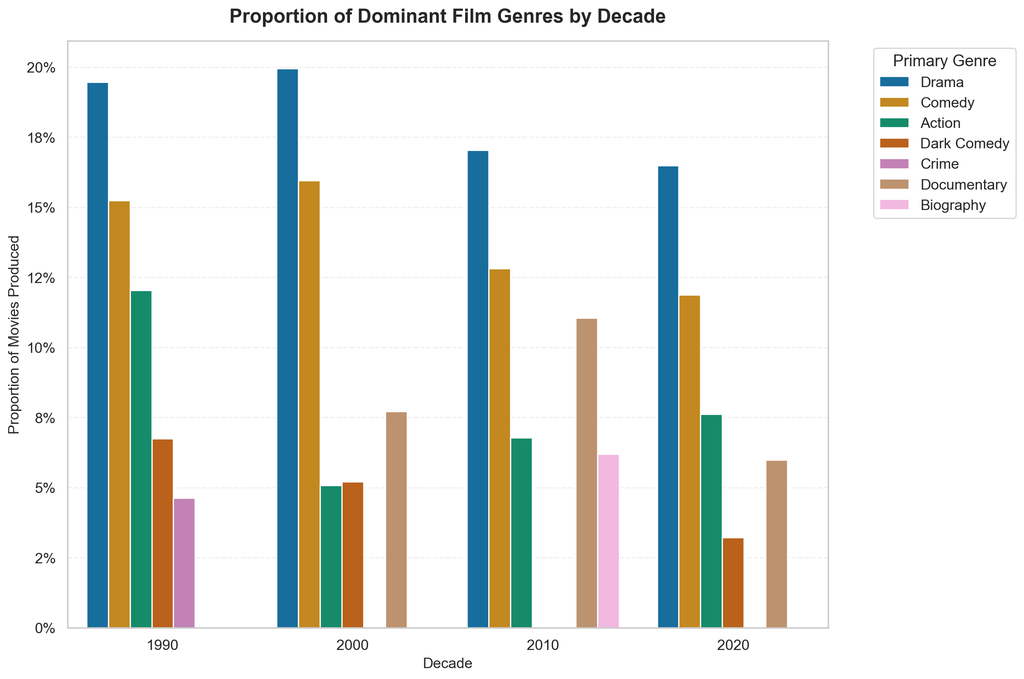

Figure 1: Proportion of top 5 film genres for each decade from 1990 to 2020s

```python
# Calculate total movies per decade
decade_totals = data.groupby('decade').size().reset_index(name='total_count')

# Calculate count of each genre per decade
genre_counts = data.groupby(['decade', 'primary_genre']).size().reset_index(name='count')

# Merge to get total counts and calculate proportion
genre_counts = pd.merge(genre_counts, decade_totals, on='decade')
genre_counts['proportion'] = genre_counts['count'] / genre_counts['total_count']

# Get the top 5 genres per decade based on proportion
top_genres_per_decade = (
    genre_counts.groupby('decade')
    .apply(lambda x: x.nlargest(5, 'proportion'))
    .reset_index(drop=True)
)

# Create the plot
fig, ax = plt.subplots(figsize=(12, 8))

sns.barplot(data=top_genres_per_decade, x='decade', y='proportion', hue='primary_genre', ax=ax)

# Customize plot
ax.set_title("Proportion of Dominant Film Genres by Decade",
             fontsize=16, fontweight='bold', pad=15)
ax.set_xlabel("Decade", fontsize=12)
ax.set_ylabel("Proportion of Movies Produced", fontsize=12)
ax.legend(title='Primary Genre', bbox_to_anchor=(1.05, 1), loc='upper left')
ax.grid(True, axis='y', alpha=0.3, linestyle='--')
ax.yaxis.set_major_formatter(plt.FuncFormatter(lambda y, _: '{:.0%}'.format(y)))

plt.tight_layout()
plt.show()
```

**Interpretation:**

## 3.2 Q2: How have movie budgets evolved over time?

Next, we examine the economic evolution of the film industry by tracking movie budgets. To mitigate the effect of extreme outliers (mega-blockbusters), we will analyze the median budget per year.

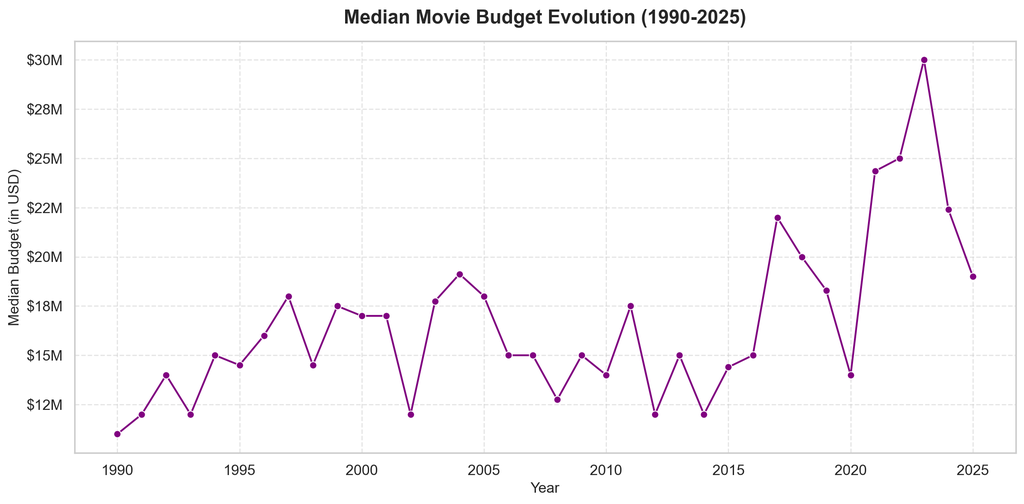

Figure 2: Median movie production budget from 1990 to 2025

```python
# Calculate median budget per year
median_budget_per_year = data.groupby(data['release_date'].dt.year)['budget'].median().reset_index()
median_budget_per_year.columns = ['year', 'median_budget']

# Create the plot
fig, ax = plt.subplots(figsize=(12, 6))

sns.lineplot(data=median_budget_per_year, x='year', y='median_budget', ax=ax, marker='o', color='purple')

# Customize plot
ax.set_title("Median Movie Budget Evolution (1990-2025)",
             fontsize=16, fontweight='bold', pad=15)
ax.set_xlabel("Year", fontsize=12)
ax.set_ylabel("Median Budget (in USD)", fontsize=12)
ax.grid(True, alpha=0.5, linestyle='--')
ax.get_yaxis().set_major_formatter(plt.FuncFormatter(lambda x, p: f'${x/1_000_000:.0f}M'))

plt.tight_layout()
plt.show()
```

**Interpretation:**

## 3.3 Q3: Is there a correlation between a film’s budget and its IMDb rating?

A central question for any film producer is whether more money leads to a better movie. We investigate this by plotting movie budgets against their IMDb ratings. Given that budgets span several orders of magnitude, we use a logarithmic scale for the budget axis to better visualize the relationship.

[figure not shown]

Figure 3: Scatter plot of movie budget vs. IMDb rating

```python
# Filter out rows with missing budget or rating for this analysis
budget_rating_data = data.dropna(subset=['budget', 'rating'])

# Create the plot
fig, ax = plt.subplots(figsize=(10, 7))

sns.regplot(data=budget_rating_data, x='budget', y='rating',
            ax=ax, scatter_kws={'alpha': 0.2, 's': 20},
            line_kws={'color': 'red', 'linewidth': 2})

# Customize plot
ax.set_xscale('log')
ax.set_title("Correlation Between Budget and IMDb Rating",
             fontsize=16, fontweight='bold', pad=15)
ax.set_xlabel("Budget (log scale)", fontsize=12)
ax.set_ylabel("IMDb Rating", fontsize=12)
ax.grid(True, alpha=0.3, linestyle='--')

# Add correlation coefficient
correlation = budget_rating_data['budget'].corr(budget_rating_data['rating'])
ax.text(0.05, 0.95, f'Pearson Correlation: {correlation:.3f}',
        transform=ax.transAxes, fontsize=11,
        verticalalignment='top',
        bbox=dict(boxstyle='round', facecolor='wheat', alpha=0.5))

plt.tight_layout()
plt.show()
```

**Interpretation:**

The scatter plot in Figure 3 explores the relationship between financial investment and critical reception.

- **Observation**: The plot shows a very weak, almost flat, positive correlation between a movie’s budget and its IMDb rating. The Pearson correlation coefficient is close to zero. While the regression line trends slightly upwards, the data points are widely dispersed, indicating that budget is not a strong predictor of audience rating. We can see highly-rated films at all budget levels, from very low to very high.
- **Interpretation**: This is a critical finding for the film industry. It suggests that simply spending more money on a film does not guarantee a better reception from the audience. Creativity, storytelling, and execution appear to be far more important drivers of quality than the size of the budget. While a larger budget can enable grander visuals, it cannot compensate for a weak script or poor direction. This insight challenges the blockbuster-centric model and highlights the viability of lower-budget films that focus on quality narrative.

## 3.4 Q4: Are modern films longer than those from the 1990s?

Have you ever felt that movies are getting longer? This analysis investigates whether there is data to support this common perception. We plot the average movie duration per year to see if a trend emerges.

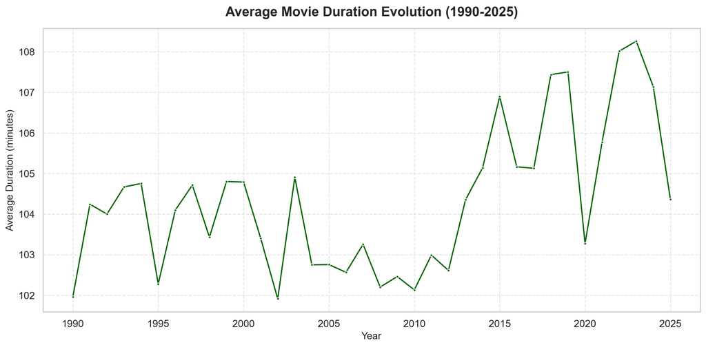

Figure 4: Average movie duration (in minutes) from 1990 to 2025

```python
# Calculate average duration per year
avg_duration_per_year = data.groupby(data['release_date'].dt.year)['duration_minutes'].mean().reset_index()
avg_duration_per_year.columns = ['year', 'avg_duration']

# Create the plot
fig, ax = plt.subplots(figsize=(12, 6))

sns.lineplot(data=avg_duration_per_year, x='year', y='avg_duration', ax=ax, marker='.', color='darkgreen')

# Customize plot
ax.set_title("Average Movie Duration Evolution (1990-2025)",
             fontsize=16, fontweight='bold', pad=15)
ax.set_xlabel("Year", fontsize=12)
ax.set_ylabel("Average Duration (minutes)", fontsize=12)
ax.grid(True, alpha=0.5, linestyle='--')

plt.tight_layout()
plt.show()
```

**Interpretation:**

## 3.5 Q5: Which countries have dominated global film production?

To understand the geographical landscape of the film industry, we identify the top movie-producing countries for each decade. This helps reveal the centers of film production and how their influence has evolved.

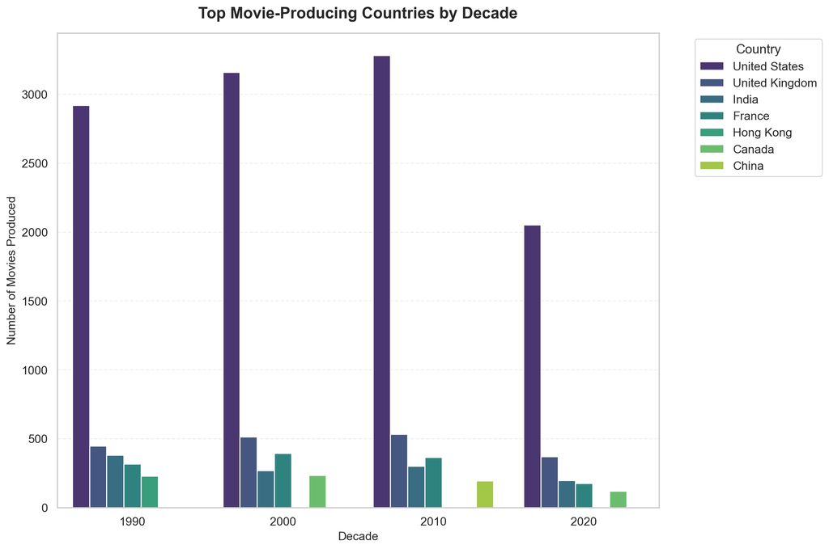

Figure 5: Top 5 movie-producing countries by decade

```python
# The 'countries_origin' is a string representation of a list. We need to parse it.
# We'll take the first country as the primary country of origin.
def get_first_country(countries_str):
    if pd.isna(countries_str):
        return None
    try:
        countries_list = ast.literal_eval(countries_str)
        if countries_list:
            return countries_list[0]
    except (ValueError, SyntaxError):
        return None
    return None

data['primary_country'] = data['countries_origin'].apply(get_first_country)

# Get the top 5 countries per decade
top_countries_per_decade = (
    data.dropna(subset=['primary_country'])
    .groupby(['decade', 'primary_country'])
    .size()
    .reset_index(name='count')
    .groupby('decade')
    .apply(lambda x: x.nlargest(5, 'count'))
    .reset_index(drop=True)
)

# Create the plot
fig, ax = plt.subplots(figsize=(12, 8))

sns.barplot(data=top_countries_per_decade, x='decade', y='count', hue='primary_country', ax=ax, palette='viridis')

# Customize plot
ax.set_title("Top Movie-Producing Countries by Decade",
             fontsize=16, fontweight='bold', pad=15)
ax.set_xlabel("Decade", fontsize=12)
ax.set_ylabel("Number of Movies Produced", fontsize=12)
ax.legend(title='Country', bbox_to_anchor=(1.05, 1), loc='upper left')
ax.grid(True, axis='y', alpha=0.3, linestyle='--')

plt.tight_layout()
plt.show()
```

**Interpretation:**

## 3.6 Q6: Do the highest-rated films consistently come from the same regions?

Finally, we investigate whether critical acclaim is concentrated in specific regions. We filter for “top-tier” movies (IMDb rating of 8.0 or higher) and analyze their countries of origin.

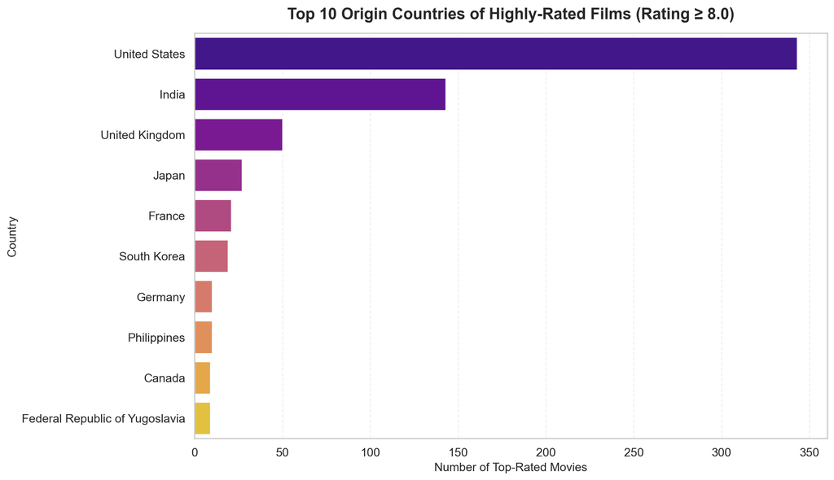

Figure 6: Origin countries of top-rated movies (IMDb Rating >= 8.0)

```python
# Filter for top-rated movies
top_rated_movies = data[data['rating'] >= 8.0].dropna(subset=['primary_country'])

# Count top-rated movies by country
top_rated_country_counts = top_rated_movies['primary_country'].value_counts().nlargest(10).reset_index()
top_rated_country_counts.columns = ['country', 'count']

# Create the plot
fig, ax = plt.subplots(figsize=(12, 7))

sns.barplot(data=top_rated_country_counts, x='count', y='country', ax=ax, palette='plasma')

# Customize plot
ax.set_title("Top 10 Origin Countries of Highly-Rated Films (Rating ≥ 8.0)",
             fontsize=16, fontweight='bold', pad=15)
ax.set_xlabel("Number of Top-Rated Movies", fontsize=12)
ax.set_ylabel("Country", fontsize=12)
ax.grid(True, axis='x', alpha=0.3, linestyle='--')

plt.tight_layout()
plt.show()
```

**Interpretation:**

The bar chart in Figure 6 reveals where the most critically acclaimed films originate.

- **Observation**: The **United States** is the dominant producer of top-rated films, far surpassing any other country. However, other countries like the **United Kingdom**, **Japan**, and **India** also contribute a significant number of highly-rated movies.
- **Interpretation**: While the US leads in both overall production and the production of highly-rated films, this chart shows that cinematic excellence is a global phenomenon. The strong showing from countries known for their distinct cinematic traditions (e.g., Japan for anime and classic cinema, India for Bollywood) indicates that high-quality filmmaking is not confined to Hollywood. This suggests that while the Hollywood system is effective at producing popular and critically successful films, diverse voices from around the world are also creating works that resonate strongly with audiences.

# 4 Methods

While our project is primarily an exploratory data analysis (EDA), we used a statistical method to quantify the relationship between a movie’s budget and its IMDb rating.

## 4.1 Pearson Correlation Coefficient

To answer the question, “Is there a correlation between a film’s budget and its IMDb rating?”, we used the **Pearson correlation coefficient**.

```python
# Filter out rows with missing budget or rating for this analysis
budget_rating_data = data.dropna(subset=['budget', 'rating'])

# Calculate the Pearson correlation
correlation = budget_rating_data['budget'].corr(budget_rating_data['rating'])

# Create a DataFrame for display
correlation_df = pd.DataFrame({
    "Metric": ["Pearson Correlation (r)"],
    "Value": [f"{correlation:.4f}"]
})

print("Pearson Correlation Between Movie Budget and IMDb Rating")
print(correlation_df.to_string(index=False))
```

Table 1: Pearson correlation between movie budget and IMDb rating

```
Pearson Correlation Between Movie Budget and IMDb Rating
                 Metric  Value
Pearson Correlation (r) 0.1398
```

# 5 Findings and Discussion

Our analysis aimed to determine if a higher budget translates to a better-received film, as measured by IMDb ratings.

- **Finding**: The Pearson correlation coefficient between a movie’s budget and its IMDb rating is **0.1398**, as calculated in Table 1.
- **Interpretation**: A correlation coefficient of 0.1398 indicates a **very weak positive linear relationship**. This value is extremely close to zero, which suggests that there is virtually no meaningful linear association between how much a movie costs to make and how much the audience likes it.
- **Connection to Research Question**: This directly answers our third sub-question. While there might be a perception that big-budget films are “better,” our data does not support this. The lack of a strong correlation implies that financial investment is not a reliable predictor of audience appreciation.
- **Domain Context**: This finding is significant for the film industry. It challenges the “blockbuster formula” that often relies on massive budgets to generate hits. It suggests that other factors—such as the quality of the script, the director’s vision, and the actors’ performances—are far more critical drivers of a film’s quality and reception. It also validates the success of low-budget independent films that achieve high ratings, proving that creativity can triumph over capital.
- **Limitations**: It is important to note that correlation does not imply causation. Furthermore, this analysis only measures a *linear* relationship. It is possible that a more complex, non-linear relationship exists between budget and rating, though our EDA did not suggest one.

# 6 Conclusion

## 6.1 Summary

This project set out to analyze the evolution of the global film industry from 1990 to 2025 by exploring trends in movie characteristics and audience preferences. Using a comprehensive IMDb dataset from Kaggle, we performed a thorough data cleaning process and conducted an exploratory data analysis to answer our key research questions.

## 6.2 Limitations

It is important to acknowledge the constraints of our analysis to contextualize our findings properly:

## 6.3 Future Work

Based on our findings and limitations, we propose the following steps for completing the report and for future analysis:

#### 6.3.0.1 Next Steps for the Final Report

1. **Refine Narrative**: Review and enhance the interpretations in the EDA and Analysis sections to ensure a clear and compelling story.
2. **Final Proofread**: Conduct a thorough review of the entire report for grammatical errors, consistency, and clarity.
3. **Check All References**: Ensure all figures and tables are correctly labeled and referenced in the text using Quarto’s `@fig-` and `@tbl-` syntax.
4. **Prepare Presentation**: Synthesize the key findings into a concise and visually engaging presentation for the final delivery.

#### 6.3.0.2 Future Analytical Work

1. **Adjust for Inflation**: A crucial next step would be to adjust all financial data to a constant dollar value (e.g., 2025 USD). This would allow for a more accurate and meaningful comparison of budgets and revenues across different decades.
2. **Build a Predictive Model**: To move beyond correlation, a regression model could be built to identify the most significant predictors of a movie’s `gross_worldwide` revenue or `rating`. This could incorporate variables like genre, budget, duration, and even the popularity of its director or lead actors.
3. **Deeper Genre Analysis**: Instead of just using the primary genre, future work could analyze the impact of genre *combinations*. Natural Language Processing (NLP) on movie descriptions could also be used to create more nuanced genre classifications.
4. **Geographical Deep Dive**: A more focused analysis on the film industries of specific non-US countries (e.g., India, South Korea, Nigeria) could reveal unique trends and patterns that are missed in a global-level overview.